# How can I level up my Overwatch performance?

## Introduction

Overwatch is a popular first-person shooter game where players work together to defeat the opposing team and complete an objective.

40 observations were collected on my own Overwatch games, with recorded variables including:

- Match outcome (Win, Loss, or Draw)
- Match duration (in seconds)
- Eliminations (players I killed during the match)
- Deaths (number of times I died during the match)
- Game mode (Control, Hybrid, Push, Escort, or Flashpoint)
- Hero type (Tank, Damage, or Support)

At the end of each Overwatch match, I use my kill/death (K/D) ratio as a measure of how well I’ve played. The K/D ratio compares the number of eliminations achieved to the number of deaths during a match, and is a common way to measure performance in first-person shooter games. To simplify aspects of my analysis and make patterns easier to identify, a new variable called Performance Level was created by grouping K/D ratios into three categories:

Excellent: K/D ratio ≥ 3

Good: 1 ≤ K/D ratio < 3

Poor: K/D ratio < 1

The following visual analysis uses both K/D Ratio and Performance Level to explore patterns in my game play, investigating how different factors affect my performance.

## How does the day of the week impact my game performance?

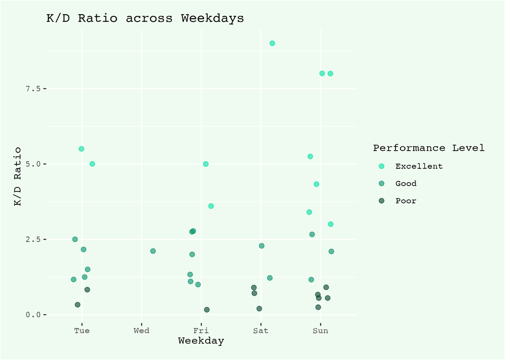

There does not appear to be a strong relationship between kill/death ratio and the day of the week, suggesting that weekday has little impact on overall game performance. Although several of the matches with the highest K/D ratios were recorded on Sundays, there is also a noticeable cluster of Poor performance matches on the same day. This indicates that while some of the best performances occurred on Sundays, performance was still highly varied. Sunday contains the largest number of recorded matches overall, which may explain why both extremely high and low K/D ratios are more concentrated on that day.

## How does the duration of the match impact my game performance?

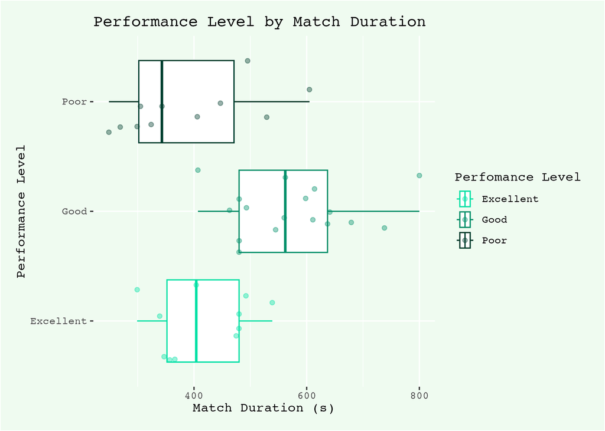

Green box plot showing Performance Level by Match Duration, coloured by Performance level.

## For matches with Poor performances, what hero types were played?

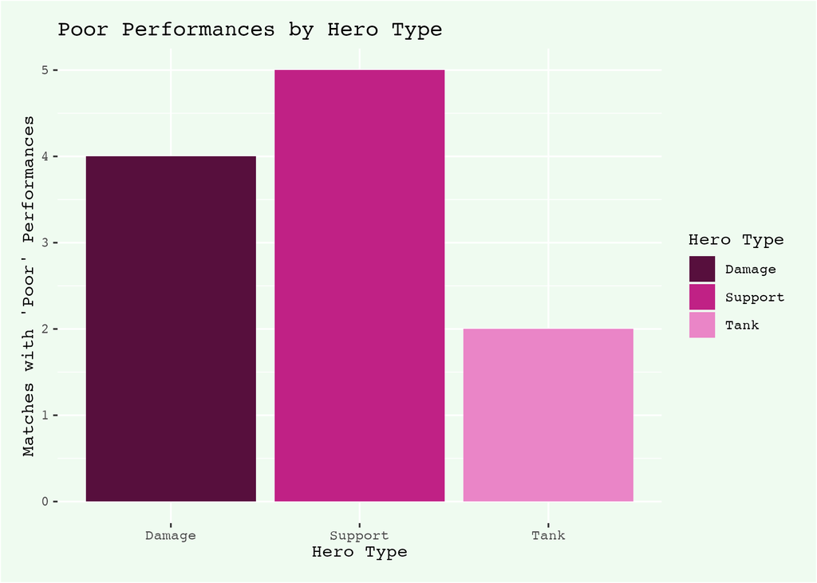

Green bar chart with pink bars showing Poor Performances by Hero Type

The hero type Support was played in the largest number of Poor matches. This suggests that my K/D ratio may be worse when playing Support compared with Damage or Tank roles. By looking at the overall spread of kill/death ratios for each hero type, we can further explore this idea.

## How does hero type impact game performance?

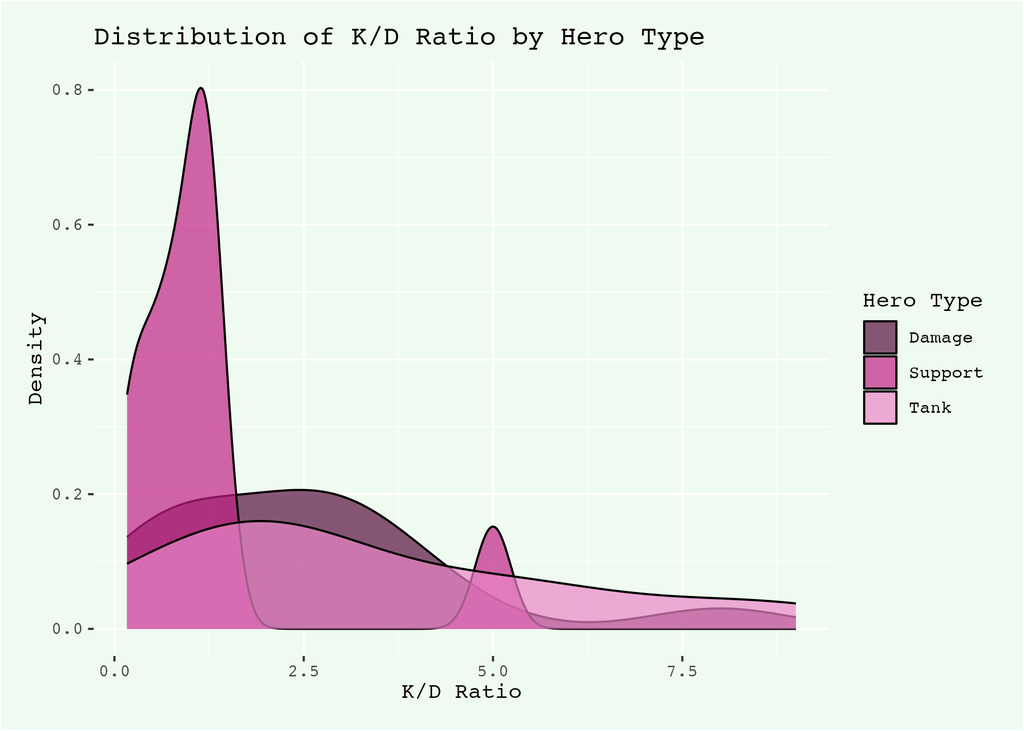

This density plot highlights clear differences in K/D ratio distributions across the three hero types. Most of my Support matches are concentrated at lower K/D ratios, while matches played with Damage and Tank heroes are spread further across higher values. As such, in my gameplay, Support heroes generally result in matches with low game performance (by my metric of K/D ratio). However, the current plot doesn’t tell us whether this is due to low eliminations or high deaths. That can be explored with the following graph.

## Why does Support have a low performance?

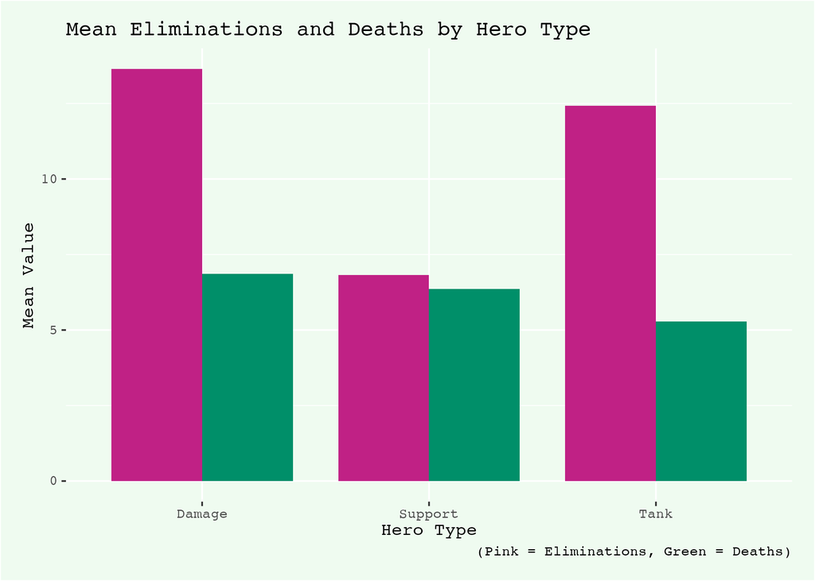

Column plot showing mean eliminations (in pink) and mean deaths (in green) by Hery Type

We can see, in the final graph, that the trend of lower K/D ratios in games played as Support is largely due to fewer eliminations in this role. The mean number of eliminations for Support is significantly lower than that of Damage and Tank. With the mean deaths being similar, it’s these fewer eliminations that are decreasing my kill/death ratio. This isn’t unusual; support characters have the ability to heal so they generally do less damage. However, since I base my performance on K/D ratio regardless of the hero role (and therefore don’t use healing to measure how well I played), it’s likely better for me to choose a non-Support role when playing Overwatch.